# Practica7TD

Carlos Santiago Martinez Torres

2025-05-14

# Creacion de fichero

Crea un proyecto llamado Practica7TD con una carpeta llamada data que contenga los ficheros de datos. Las soluciones al ejercicio propuesto se incluirán en un fichero llamado Practica7TD.Rmd en el directorio raíz del proyecto.

# Carga de datos

1. Carga en un data frame el contenido del fichero de datos licores.csv. Verifica que las columnas tienen el tipo de dato adecuado a su contenido. Muestra las primeras 10 filas.

```r
# Carga de datos
licores <- read.csv(file = 'data/licores.csv', header = TRUE)

# Verificacion del tipo de dato
glimpse(licores)
```

```
## Rows: 1,599
## Columns: 12
## $ fixed.acidity        <dbl> 7.4, 7.8, 7.8, 11.2, 7.4, 7.4, 7.9, 7.3, 7.8, 7.5…
## $ volatile.acidity     <dbl> 0.700, 0.880, 0.760, 0.280, 0.700, 0.660, 0.600, …
## $ citric.acid          <dbl> 0.00, 0.00, 0.04, 0.56, 0.00, 0.00, 0.06, 0.00, 0…
## $ residual.sugar       <dbl> 1.9, 2.6, 2.3, 1.9, 1.9, 1.8, 1.6, 1.2, 2.0, 6.1,…
## $ chlorides            <dbl> 0.076, 0.098, 0.092, 0.075, 0.076, 0.075, 0.069, …
## $ free.sulfur.dioxide  <dbl> 11, 25, 15, 17, 11, 13, 15, 15, 9, 17, 15, 17, 16…
## $ total.sulfur.dioxide <dbl> 34, 67, 54, 60, 34, 40, 59, 21, 18, 102, 65, 102,…
## $ density              <dbl> 0.9978, 0.9968, 0.9970, 0.9980, 0.9978, 0.9978, 0…
## $ pH                   <dbl> 3.51, 3.20, 3.26, 3.16, 3.51, 3.51, 3.30, 3.39, 3…
## $ sulphates            <dbl> 0.56, 0.68, 0.65, 0.58, 0.56, 0.56, 0.46, 0.47, 0…
## $ alcohol              <dbl> 9.4, 9.8, 9.8, 9.8, 9.4, 9.4, 9.4, 10.0, 9.5, 10.…
## $ quality              <int> 5, 5, 5, 6, 5, 5, 5, 7, 7, 5, 5, 5, 5, 5, 5, 5, 7…
```

```r
# Mostrar las primeras 10 filas
head(x = licores, 10)
```

```
##    fixed.acidity volatile.acidity citric.acid residual.sugar chlorides
## 1            7.4             0.70        0.00            1.9     0.076
## 2            7.8             0.88        0.00            2.6     0.098
## 3            7.8             0.76        0.04            2.3     0.092
## 4           11.2             0.28        0.56            1.9     0.075
## 5            7.4             0.70        0.00            1.9     0.076
## 6            7.4             0.66        0.00            1.8     0.075
## 7            7.9             0.60        0.06            1.6     0.069
## 8            7.3             0.65        0.00            1.2     0.065
## 9            7.8             0.58        0.02            2.0     0.073
## 10           7.5             0.50        0.36            6.1     0.071
##    free.sulfur.dioxide total.sulfur.dioxide density   pH sulphates alcohol
## 1                   11                   34  0.9978 3.51      0.56     9.4
## 2                   25                   67  0.9968 3.20      0.68     9.8
## 3                   15                   54  0.9970 3.26      0.65     9.8
```

[output cut: 18 more lines]

2. Indica el número de filas, tipo de datos de cada columna y sus estadísticos básicos. ¿Hay valores especiales (NaN, NA,Inf,-Inf) en alguna columna?

```r
# Valores especiales
sum(is.na(x = licores))
```

```
## [1] 0
```

```r
# Numero de filas
dim(x = licores)[1]
```

```
## [1] 1599
```

```r
# Estadisticos básicos
summary(licores)
```

```
##  fixed.acidity   volatile.acidity  citric.acid    residual.sugar
##  Min.   : 4.60   Min.   :0.1200   Min.   :0.000   Min.   : 0.900
##  1st Qu.: 7.10   1st Qu.:0.3900   1st Qu.:0.090   1st Qu.: 1.900
##  Median : 7.90   Median :0.5200   Median :0.260   Median : 2.200
##  Mean   : 8.32   Mean   :0.5278   Mean   :0.271   Mean   : 2.539
##  3rd Qu.: 9.20   3rd Qu.:0.6400   3rd Qu.:0.420   3rd Qu.: 2.600
##  Max.   :15.90   Max.   :1.5800   Max.   :1.000   Max.   :15.500
##    chlorides       free.sulfur.dioxide total.sulfur.dioxide    density
##  Min.   :0.01200   Min.   : 1.00       Min.   :  6.00       Min.   :0.9901
##  1st Qu.:0.07000   1st Qu.: 7.00       1st Qu.: 22.00       1st Qu.:0.9956
##  Median :0.07900   Median :14.00       Median : 38.00       Median :0.9968
##  Mean   :0.08747   Mean   :15.87       Mean   : 46.47       Mean   :0.9967
##  3rd Qu.:0.09000   3rd Qu.:21.00       3rd Qu.: 62.00       3rd Qu.:0.9978
##  Max.   :0.61100   Max.   :72.00       Max.   :289.00       Max.   :1.0037
##        pH          sulphates         alcohol         quality
##  Min.   :2.740   Min.   :0.3300   Min.   : 8.40   Min.   :3.000
##  1st Qu.:3.210   1st Qu.:0.5500   1st Qu.: 9.50   1st Qu.:5.000
##  Median :3.310   Median :0.6200   Median :10.20   Median :6.000
##  Mean   :3.311   Mean   :0.6581   Mean   :10.42   Mean   :5.636
##  3rd Qu.:3.400   3rd Qu.:0.7300   3rd Qu.:11.10   3rd Qu.:6.000
##  Max.   :4.010   Max.   :2.0000   Max.   :14.90   Max.   :8.000
```

C. Sustituye en los nombres de las variables el carácter espacio ’ ’ por el carácter barra baja ’_’.

```r
# Nombre de las variables
colnames(x = licores) <- str_replace_all(string = colnames(x = licores), pattern = '[ .]' , replacement = '_')
colnames(x = licores)
```

```
##  [1] "fixed_acidity"        "volatile_acidity"     "citric_acid"
##  [4] "residual_sugar"       "chlorides"            "free_sulfur_dioxide"
##  [7] "total_sulfur_dioxide" "density"              "pH"
## [10] "sulphates"            "alcohol"              "quality"
```

# Preparación de datos

1. ¿Qué valores distintos contiene la variable quality? Conviértela a factor y asigna el valor de sus niveles a ‘Muy malo’, ‘Malo’, ‘Regular’, ‘Aprobado’, ‘Bueno’ y ‘Muy bueno’, por orden de menor a mayor valoración. ¿Cuántas muestras (filas) corresponden a cada nivel?

```r
# Valor de los niveles
etiqueta <- c('Muy malo', 'Malo', 'Regular', 'Aprobado', 'Bueno', 'Muy bueno')

# factor(x,
#        levels = unique(x),  # Especificar el orden de los niveles
#        labels = levels,     # Nombres alternativos para los niveles
#        ordered = FALSE,     # Para factores ordinales
#        exclude = NA)        # Valores a excluir

niveles <- licores %>%
  distinct(quality) %>%
  arrange(quality) %>%
  as.vector(.)

niveles <- niveles[[1]]

# Contamos antes de hacer el factor para verificar
licores %>%
  count(quality)
```

```
##   quality   n
## 1       3  10
## 2       4  53
## 3       5 681
## 4       6 638
## 5       7 199
## 6       8  18
```

```r
# Convertimos a factor
licores <- licores %>%
  mutate(quality = factor(x = quality, levels = niveles, labels = etiqueta, ordered = TRUE))

licores %>%
  count(quality)
```

```
##     quality   n
## 1  Muy malo  10
## 2      Malo  53
## 3   Regular 681
## 4  Aprobado 638
## 5     Bueno 199
## 6 Muy bueno  18
```

2. Realiza las siguientes operaciones:
- Crea otra columna llamada sulfur_dioxide_ratio que contenga el resultado del cociente entra las columnas free_sulfur_dioxide y total_sulfur_dioxide.

```r
licores %>%
  mutate(sulfur_dioxide_ratio = free_sulfur_dioxide/total_sulfur_dioxide)
```

- Elimina las dos columnas que has usado para el cálculo. Elimina también la columna chlorides.

```r
licores %>%
  select(-free_sulfur_dioxide, -total_sulfur_dioxide, -chlorides)
```

- Elimina las filas con un citric acid < 0.05.

```r
licores %>%
  filter(!citric_acid < 0.05)
```

- Ordena las filas de mayor a menor valor de alcohol.

```r
licores %>%
  arrange(desc(alcohol))
```

- Redondea todas las variables numéricas a un máximo de 3 decimales.

```r
licores %>%
  mutate(across(.cols = where(is.numeric),
                .fns = ~round(., 3)))
```

Enlaza TODAS las operaciones con tuberías y guarda el data frame resultante en la variable datos_proc.

```r
datos_proc <- licores %>%
  mutate(sulfur_dioxide_ratio = free_sulfur_dioxide/total_sulfur_dioxide) %>%
  select(-free_sulfur_dioxide, -total_sulfur_dioxide, -chlorides) %>%
  filter(!citric_acid < 0.05) %>%
  arrange(desc(alcohol)) %>%
  mutate(across(.cols = where(is.numeric),
                .fns = ~round(., 3)))

head(datos_proc, 5)
```

```
##   fixed_acidity volatile_acidity citric_acid residual_sugar density   pH
## 1          15.9             0.36        0.65            7.5   0.998 2.98
## 2           8.8             0.46        0.45            2.6   0.995 3.32
## 3           5.0             0.42        0.24            2.0   0.992 3.72
## 4           5.0             0.40        0.50            4.3   0.990 3.49
## 5           7.4             0.36        0.34            1.8   0.993 3.38
##   sulphates alcohol   quality sulfur_dioxide_ratio
## 1      0.84    14.9   Regular                0.310
## 2      0.79    14.0  Aprobado                0.389
## 3      0.74    14.0 Muy bueno                0.380
## 4      0.66    13.6  Aprobado                0.362
## 5      0.88    13.6     Bueno                0.474
```

A partir de ahora debes usar el dataframe datos_proc que has obtenido. NOTA: Si no has resuelto el anterior ejercicio, usa el data frame que se proporciona en el fichero datos_proc.Rdata incluido en la carpeta data, para responder a las siguientes preguntas:

4. Determina, para cada valor de quality, la media, mediana, desviación estándar y rango intercuartílico de los valores de alcohol, redondeando a 2 decimales. Confecciona una tabla como la siguiente. Fíjate que se debe combinar media±sd en la misma columna. ¿Observas alguna relación entre el nivel de alcohol y la calidad del licor?

```r
# Estadísticos de todas las columnas numéricas
funs_apply = list('mean' = mean, 'median' = median, 'sd' = sd, 'IQR' = IQR)

valores_alcohol <- datos_proc %>%
  group_by(quality) %>%
  summarise(across(.cols = alcohol,
                   .fns = funs_apply,
                   .names = '{.fn}')) %>%
  mutate('mean+sd' = mean+sd) %>%
  mutate(across(.cols = where(is.numeric),
                .fns = ~ round(., 2)))

valores_alcohol
```

```
## # A tibble: 6 × 6
##   quality    mean median    sd   IQR `mean+sd`
##   <ord>     <dbl>  <dbl> <dbl> <dbl>     <dbl>
## 1 Muy malo   9.44    9.7  0.73   0.9      10.2
## 2 Malo      10.3    10    0.99   1.4      11.3
## 3 Regular    9.89    9.6  0.75   0.8      10.6
## 4 Aprobado  10.6    10.5  1.03   1.5      11.6
## 5 Bueno     11.4    11.4  0.93   1.3      12.3
## 6 Muy bueno 12.0    11.8  1.16   1.5      13.1
```

```r
# Si hay relacion entre nivel de alcohol y la calidad del licor
```

# Datos anomalos

1. Determina si hay algún dato anómalo en las variables numéricas usando las reglas Hampel y Boxplot. Para cada variable añadirás 2 columnas adicionales. Una al aplicar la regla de Hampel y otra al aplicar la regla del Boxplot que indicará si dicho valor es un outlier (TRUE) o no (FALSE). Suma el número de casos para cada combinación de regla y variable y guarda los resultados como una fila en un data frame outliers.

```r
# Funcion que recibe una columna y evalua la desviacion absoluta de la mediana'median absolute deviation from the median'
madm <- function(v) {
  mediana <- median(v, na.rm=TRUE) # Cada vez que 'opera el vector', considera los na.
  valor <- 1.4826 * median(abs(v - mediana), na.rm=TRUE)
  return(valor)
}


# Funcion para Identificador Hampel
reglahampel <- function(v) {
  mediana <- median(v, na.rm = TRUE)
  madm <- madm(v)
  return((v < (mediana - (3 * madm)) | (v > (mediana + (3 * madm)))))
}


# Funcion Regla boxplot
reglaboxplot <- function(v){
  xi <- quantile(v, probs =  0.25, na.rm=TRUE)
  xs <- quantile(v, probs =  0.75, na.rm=TRUE)
  iqr <- xs - xi
  return((v < (xi - (1.5 * iqr))) | (v > (xs + (1.5 * iqr))))
}

outliers <- datos_proc %>%
  mutate(across(.cols = where(is.numeric),
               .fns = list(reglahampel = reglahampel,
                          reglaboxplot = reglaboxplot))) %>%
  summarise(across(.cols = where(is.logical),
                  .fns = ~sum(., na.rm = TRUE)))
```

2. Representa mediante un diagrama de barras la cantidad de outliers detectada para cada variable y en diferente color para cada regla. Coloca las barras unas al lado de las otras.

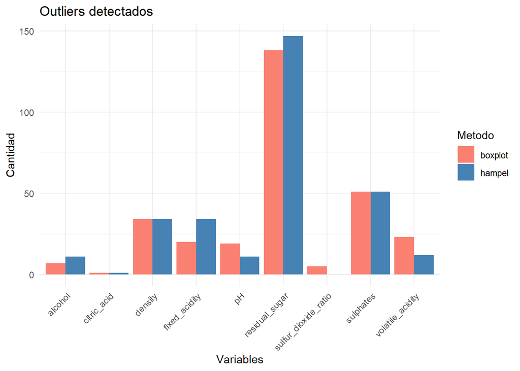

```r
# Convertir a pivot longer para graficar por variable
outliers <- outliers %>%
  pivot_longer(cols = everything(),
               names_to = c('variable'),
               values_to = 'valor')

outliers <- outliers %>%
  separate(col = "variable",
           into = c("variable", "metodo"),
           sep = "_regla")

ggplot(outliers, aes(x = variable, y = valor, fill = metodo)) +
  geom_bar(stat = 'identity',
           position = position_dodge()) +
  labs(title = 'Outliers detectados',
       x = 'Variables',
       y = 'Cantidad',
       fill = 'Metodo') +
  scale_fill_manual(values = c("hampel" = "steelblue", "boxplot" = "salmon")) +
  theme_minimal() +
  theme(axis.text.x = element_text(angle = 45, hjust = 1))
```

3. Representa, mediante un gráfico adecuado, la dispersión del nivel de alcohol según la variable quality, que además muestre los outliers determinados con la regla del boxplot. ¿ qué grado de calidad presenta mayor número de outliers ?

```r
#
```

# Matriz

Obtén la matriz de correlaciones de Pearson entre todas las variables numéricas en datos_proc. ¿Cuáles son las variables con mayor correlación? Realiza una representación gráfica de scatter entre las variables numéricas del conjunto.

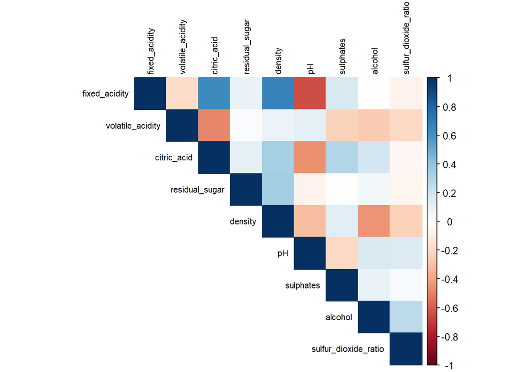

```r
matrix <- cor(select(datos_proc, where(is.numeric)), use = "complete.obs")

corrplot(matrix, method = "color", type = "upper", tl.cex = 0.7, tl.col = "black")
```

# Rep graficas

Representaciones gráficas. Partiendo del data frame datos_proc realiza las siguientes tareas:

1. Representa superpuestos los histogramas de densidad de la variable alcohol para cada valor de quality. Aplica un alpha de 0.5 al histograma. Añade una línea de densidad con un color distinto para cada histograma.

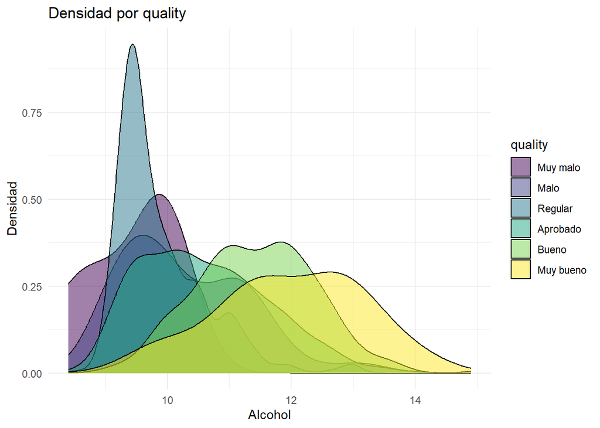

```r
ggplot(datos_proc, aes(x = alcohol, fill = quality)) +
  geom_density(alpha = 0.5) +
  labs(title = 'Densidad por quality', x = 'Alcohol', y = 'Densidad') +
  theme_minimal()
```

2. Representa un diagrama de dispersión entre citric_acid y fixed_acidity, incuyendo jitter. Usa un color de punto distinto para cada valor de quality y un tamaño de punto proporcional a residual_sugar. Ajusta un modelo (método por defecto) para cada valor de quality sin representar la desviación estándar.

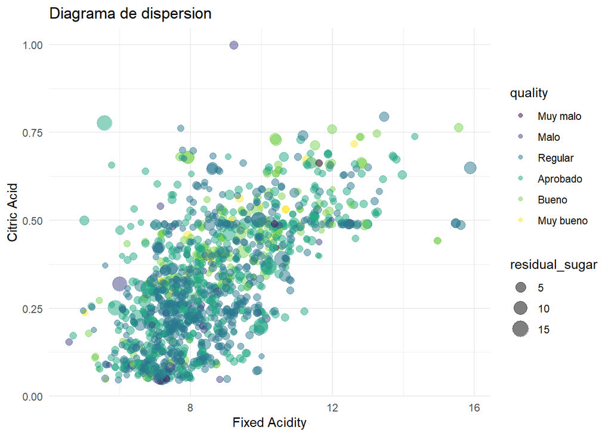

```r
ggplot(datos_proc, aes(x = fixed_acidity, y = citric_acid, color = quality, size = residual_sugar)) +
  geom_jitter(alpha = 0.5) +
  labs(title = 'Diagrama de dispersion', x = 'Fixed Acidity', y = 'Citric Acid') +
  theme_minimal()
```

3. Representa un diagrama de cajas de pH en función de quality. ¿Cómo se relaciona la calidad del licor con su pH? Añade un gráfico de dispersión para cada caja, incluyendo jitter, coloreando los puntos según citric_acid y su tamaño proporcional a density, con un alpha de 0.1.

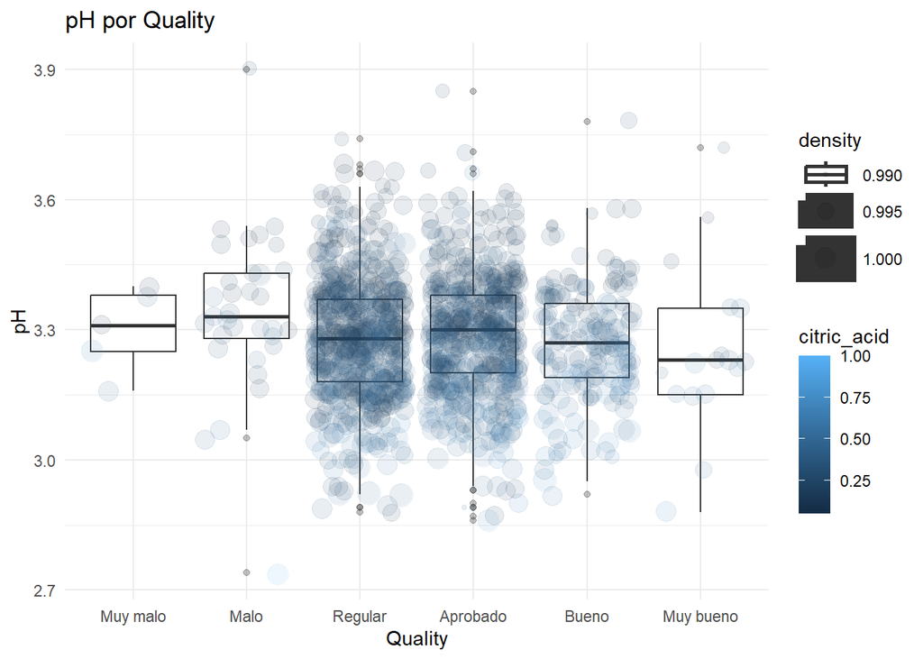

```r
ggplot(datos_proc, aes(x = quality, y = pH, color = citric_acid, size = density)) +
  geom_boxplot(outlier.alpha = 0.3) +
  geom_jitter(alpha = 0.1) +
  labs(title = 'pH por Quality', x = 'Quality', y = 'pH') +
  theme_minimal()
```